# Analysis of State-Level Happiness and Population Density in the United States

After taking a look at the happiness scores by each country and what factors are influencial in determining people’s happiness, I wanted to examine the relationship between happiness scores and population density across U.S. states to get an idea of whether the same factors that influenced the happiness scores have the same impact on state-level or not. Also, analyses of the relationship between the happiness score and its factors didn’t seem to give accurate results, especially for the coastal/non-coastal area where most countries were categorized as ‘coastal’, so I decided to go into more detail and analyzed the relationship by narrowing the scope.

For this section, I started analyzing the data by categorizing states based on population density and analyzing happiness scores.

```r
# Load libraries
library(tidyverse)
library(sf)
library(spdep)
library(viridis)
library(readxl)
library(rnaturalearth)
library(rnaturalearthdata)
library(corrplot)
```

```r
# Load spatial and happiness datasets
us_states <- ne_states(country = "United States of America", returnclass = "sf")
happiness_state <- read_csv("../data/happiest-states-2024.csv", show_col_types = FALSE)
```

```r
# Merge spatial and happiness data
merged_sf <- left_join(us_states, happiness_state, by = c("name" = "state"))
merged_sf <- merged_sf[!is.na(merged_sf$HappiestStatesTotalHappinessScore), ] # Remove rows with missing happiness scores
```

```r
merged_sf <- st_transform(merged_sf, crs = 3857)
```

```r
country_area <- read_csv("../data/united-states-by-density-2024.csv", show_col_types = FALSE)
```

```r
merged_sf <- left_join(merged_sf, country_area, by = c("name" = "state"))
```

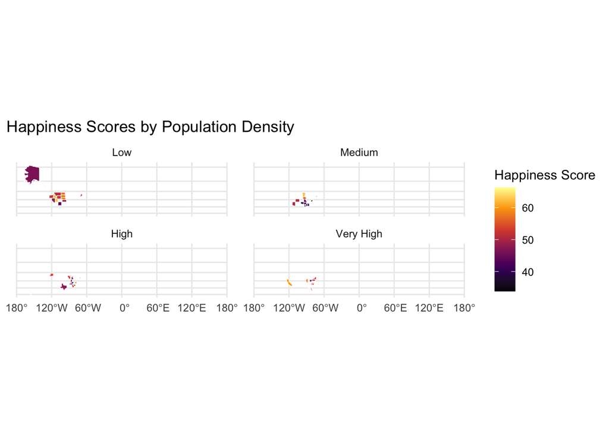

```r
# Categorize countries by population density
merged_sf$pop_density_category <- cut(
  merged_sf$densityMi,
  breaks = quantile(merged_sf$densityMi, probs = seq(0, 1, by = 0.25), na.rm = TRUE),
  labels = c("Low", "Medium", "High", "Very High"),
  include.lowest = TRUE
)

# Visualize happiness by population density
ggplot(merged_sf) +
  geom_sf(aes(fill = HappiestStatesTotalHappinessScore), color = "white") +
  facet_wrap(~pop_density_category) +
  scale_fill_viridis_c(option = "B") +
  theme_minimal() +
  labs(title = "Happiness Scores by Population Density", fill = "Happiness Score")
```

I used the happiness data that has the happiness scores of people in each state, measured in 2024, and merged it with the population density data that has the density for each state. Then, I categorized the population density into four parts, low, medium, high, very high density, so that I could get a better understanding of whether population densities influence people’s happiness and see whether a low or high density affects people’s sentiment.

### Exploratory Insights

From this scatterplot, it revealed that there isn’t a clear linear relationship between population density and happiness scores. While some low-density states exhibit high happiness, other density categories display mixed results, suggesting additional factors influencing well-being.

### Spatial Autocorrelation Analysis

To look into closer of whether the scatterplot showed the correct result, I used Moran’s I to test the following hypothesis:

H0: Happiness levels are not determined by the neighboring states. Ha: Happiness levels are determined by the neighboring states.

```r
merged_sf <- merged_sf[!is.na(merged_sf$`pop_density_category`), ] # Remove rows with missing happiness scores
```

```r
# Subset coastal and landlocked countries
low_den_countries <- merged_sf[merged_sf$pop_density_category == "Low", ]
mod_den_countries <- merged_sf[merged_sf$pop_density_category == "Medium", ]
high_den_countries <- merged_sf[merged_sf$pop_density_category == "High", ]
very_high_den_countries <- merged_sf[merged_sf$pop_density_category == "Very High", ]

# Create spatial weights for Low Freedom countries
low_den_coords <- st_coordinates(st_centroid(low_den_countries))
low_den_knn <- spdep::knearneigh(low_den_coords, k = 5)
low_den_listw <- spdep::nb2listw(spdep::knn2nb(low_den_knn), style = "W")

# Moran's I for Low Freedom countries
low_den_moran <- spdep::moran.test(low_den_countries$`HappiestStatesTotalHappinessScore`, low_den_listw)
print(low_den_moran)
```

```
    Moran I test under randomisation

data:  low_den_countries$HappiestStatesTotalHappinessScore
weights: low_den_listw

Moran I statistic standard deviate = -0.41199, p-value = 0.6598
alternative hypothesis: greater
sample estimates:
Moran I statistic       Expectation          Variance
      -0.12950481       -0.08333333        0.01255955
```

```r
# Create spatial weights for Moderate Freedom countries
mod_den_coords <- st_coordinates(st_centroid(mod_den_countries))
mod_den_knn <- spdep::knearneigh(mod_den_coords, k = 5)
mod_den_listw <- spdep::nb2listw(spdep::knn2nb(mod_den_knn), style = "W")

# Moran's I for Moderate Freedom countries
mod_den_moran <- spdep::moran.test(mod_den_countries$`HappiestStatesTotalHappinessScore`, mod_den_listw)
print(mod_den_moran)
```

```
    Moran I test under randomisation

data:  mod_den_countries$HappiestStatesTotalHappinessScore
weights: mod_den_listw

Moran I statistic standard deviate = 3.5085, p-value = 0.0002254
alternative hypothesis: greater
sample estimates:
Moran I statistic       Expectation          Variance
      0.246862485      -0.090909091       0.009268627
```

```r
# Create spatial weights for High Freedom countries
high_den_coords <- st_coordinates(st_centroid(high_den_countries))
high_den_knn <- spdep::knearneigh(high_den_coords, k = 5)
high_den_listw <- spdep::nb2listw(spdep::knn2nb(high_den_knn), style = "W")

# Moran's I for High Freedom countries
high_den_moran <- spdep::moran.test(high_den_countries$`HappiestStatesTotalHappinessScore`, high_den_listw)
print(high_den_moran)
```

```
    Moran I test under randomisation

data:  high_den_countries$HappiestStatesTotalHappinessScore
weights: high_den_listw

Moran I statistic standard deviate = 0.29169, p-value = 0.3853
alternative hypothesis: greater
sample estimates:
Moran I statistic       Expectation          Variance
     -0.067284020      -0.090909091       0.006560212
```

```r
# Create spatial weights for High Freedom countries
very_high_den_coords <- st_coordinates(st_centroid(very_high_den_countries))
very_high_den_knn <- spdep::knearneigh(very_high_den_coords, k = 5)
very_high_den_listw <- spdep::nb2listw(spdep::knn2nb(very_high_den_knn), style = "W")

# Moran's I for High Freedom countries
very_high_den_moran <- spdep::moran.test(very_high_den_countries$`HappiestStatesTotalHappinessScore`, very_high_den_listw)
print(very_high_den_moran)
```

```
    Moran I test under randomisation

data:  very_high_den_countries$HappiestStatesTotalHappinessScore
weights: very_high_den_listw

Moran I statistic standard deviate = -0.22418, p-value = 0.5887
alternative hypothesis: greater
sample estimates:
Moran I statistic       Expectation          Variance
      -0.10619418       -0.08333333        0.01039873
```

After calculating the Moran’s I for different population densities, it showed that for low, high, and very high density states, the p-value was more than 0.05 and didn’t reveal any significance. Yet, for the population density categorized as “medium”, the p-value was 0.0002, which showed there was significant clustering. This suggests neighboring medium-density states tend to have similar happiness scores.

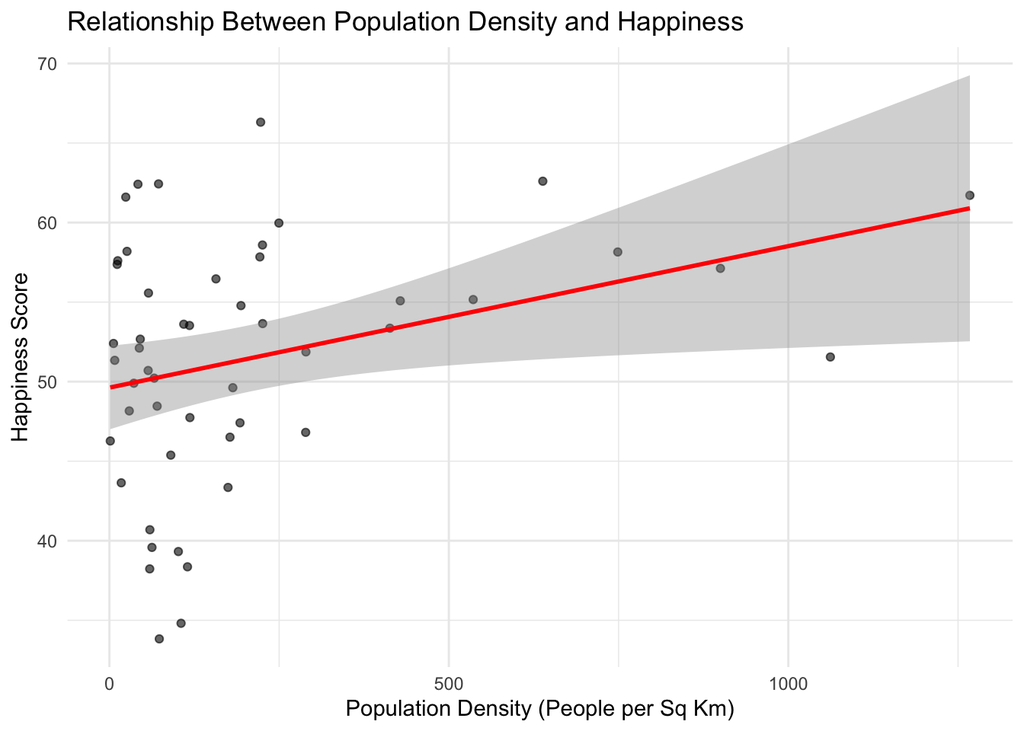

```r
# Scatterplot of Population Density vs. Happiness Score
ggplot(merged_sf, aes(x = densityMi, y = `HappiestStatesTotalHappinessScore`)) +
  geom_point(alpha = 0.6) +
  geom_smooth(method = "lm", color = "red", se = TRUE) +
  theme_minimal() +
  labs(
    title = "Relationship Between Population Density and Happiness",
    x = "Population Density (People per Sq Km)",
    y = "Happiness Score"
  )
```

### Population Density Moran’s I

```r
# Compute Moran's I for Population Density
pop_density_nb <- spdep::poly2nb(merged_sf, queen = TRUE)

# Allow empty neighbor sets
pop_density_listw <- spdep::nb2listw(pop_density_nb, style = "W", zero.policy = TRUE)

# Compute Moran's I for Population Density
pop_density_moran <- spdep::moran.test(merged_sf$densityMi, pop_density_listw, zero.policy = TRUE)

# Print the Moran's I result
print(pop_density_moran)
```

```
    Moran I test under randomisation

data:  merged_sf$densityMi
weights: pop_density_listw
n reduced by no-neighbour observations

Moran I statistic standard deviate = 5.6751, p-value = 6.929e-09
alternative hypothesis: greater
sample estimates:
Moran I statistic       Expectation          Variance
      0.502672670      -0.021276596       0.008523655
```

A separate Moran’s I test for population density revealed significant spatial clustering (Moran’s I = 0.50, p-value < 0.001). States with similar density levels are geographically proximate, highlighting the influence of regional factors like urban planning, geography, and historical settlement patterns.

### K-Means clustering

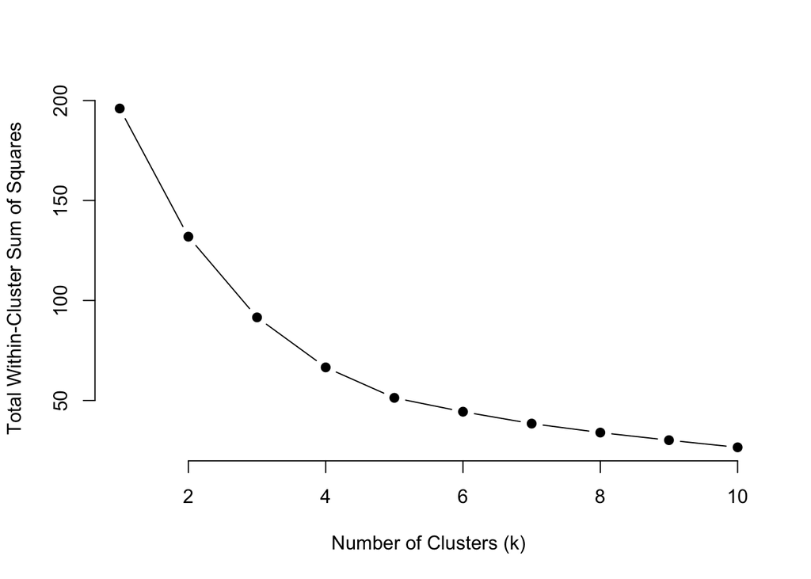

```r
# Subset relevant data (e.g., happiness scores and other numeric variables)
cluster_data <- merged_sf %>%
  st_drop_geometry() %>%  # Remove spatial geometry
  select(HappiestStatesTotalHappinessScore, densityMi, HappiestStatesCommunityAndEnvironmentRank, HappiestStatesWorkEnvironmentRank) %>%
  drop_na()  # Remove rows with missing values

# Standardize the data
cluster_data_scaled <- scale(cluster_data)

# Determine the optimal number of clusters using the Elbow method
set.seed(123)  # For reproducibility
wss <- map_dbl(1:10, function(k) {
  kmeans(cluster_data_scaled, centers = k, nstart = 25)$tot.withinss
})

# Plot the Elbow method
plot(1:10, wss, type = "b", pch = 19, frame = FALSE,
     xlab = "Number of Clusters (k)",
     ylab = "Total Within-Cluster Sum of Squares")
```

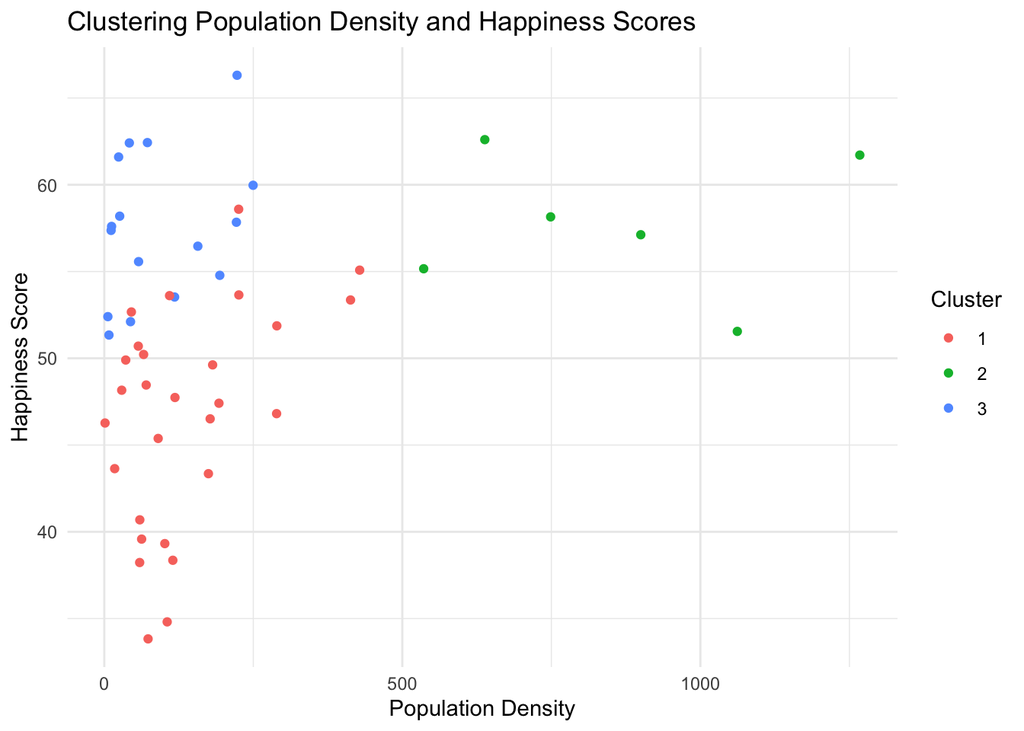

```r
# Perform k-means clustering with the optimal number of clusters
optimal_k <- 3  # Replace with the optimal number from the Elbow plot
kmeans_result <- kmeans(cluster_data_scaled, centers = optimal_k, nstart = 25)

# Add cluster assignments to the original dataset
merged_sf$cluster <- as.factor(kmeans_result$cluster)

# Scatterplot
ggplot(merged_sf, aes(x = densityMi, y = HappiestStatesTotalHappinessScore, color = cluster)) +
  geom_point() +
  theme_minimal() +
  labs(title = "Clustering Population Density and Happiness Scores",
       x = "Population Density",
       y = "Happiness Score",
       color = "Cluster")
```

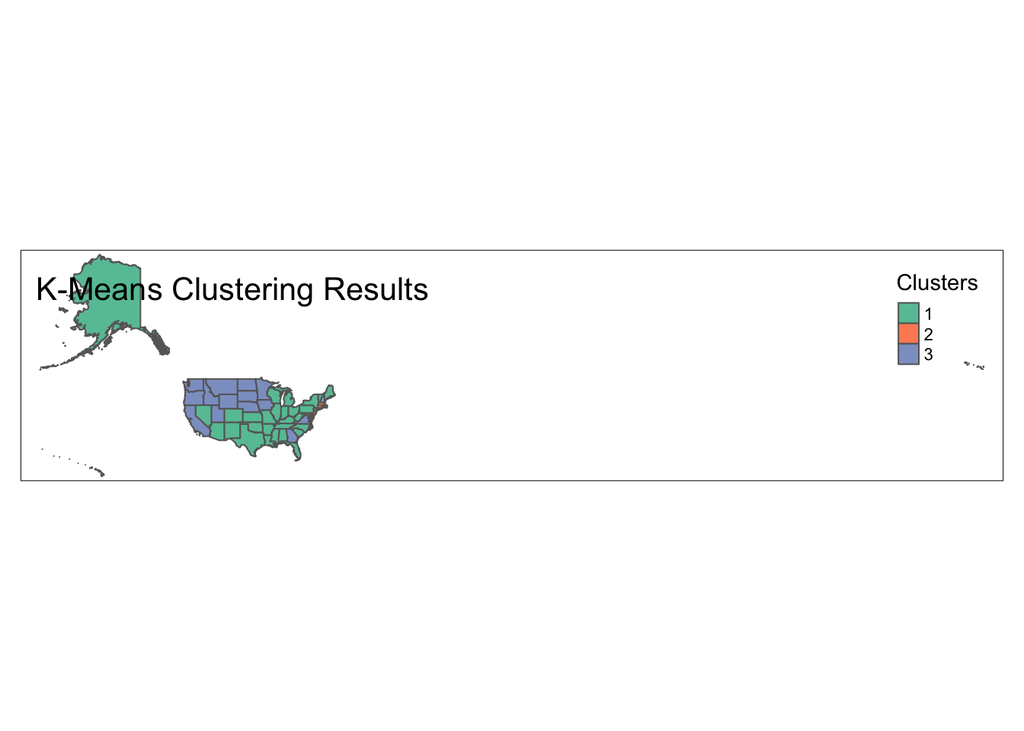

```r
# Visualize clusters on a map
library(tmap)
tm_shape(merged_sf) +
  tm_polygons("cluster", palette = "Set2", title = "Clusters") +
  tm_layout(title = "K-Means Clustering Results")
```

The K-means clustering analysis highlighted significant groupings of states based on happiness scores and population density. The analysis revealed that states with higher population densities tended to cluster separately from less densely populated regions, indicating potential differences in living conditions, access to resources, or societal structures. Additionally, happiness scores showed clear patterns within the clusters, with some groups exhibiting consistently high levels of happiness, while others were lower on average.

### Findings

- Population density does not directly correlate with happiness, but medium-density states show significant spatial clustering, suggesting some geographic influence on well-being.
- Policymakers should consider regional trends and unique state characteristics when addressing well-being. Medium-density states could benefit from targeted initiatives to enhance happiness, while high-density states may require diverse strategies to address urban challenges.